# Sign Lenguaje

Entrenamiento y predicción de imagenes en tiempo real  
Deep Learning - Convolutional Neural Network

Autor/a

Javier Nuñez

Fecha de publicación

3 de enero, 2026

## 1 📌 Descripción

Proyecto que busca entrenar una red neuronal convolucional (CNN) para predecir, en tiempo real, los numeros del 0 al 9 en lenguaje de señas. Para ello, se trabaja con dos instancias independientes pero relacionadas: 1. Entrenamiento del modelo 2. Prediccion en tiempo real utilizando alguno de los modelos entrenados

## 2 ⚠️ Disclaimer

El proyecto no busca la excelencia. Las imagenes utilizadas para el entrenamiento son relativamente pocas, de dimensiones (100, 100, 3), y en baja calidad, por lo que no es de esperar que los resultados de las predicciones sean totalmente acertados.

## 3 🚀 Funcionalidades Clave

- **Procesamiento de imagenes:** Analisis de las imagenes que se utilizan para el entrenamiento, y generacion de carpetas (una por categoria).
- **Modelado:** Implementación de algoritmos de Deep Learning + Data Augmentation (opcional) + Transfer Learning (Opcional)
- **Visualización:** Prediccion en tiempo real mediante keras & OpenCV.

## 4 🛠️ Stack Tecnológico

- **Lenguaje:** Python 3.11.7
- **Librerías principales:** Tensorflow 2.20.0, Keras 3.12.0, Scikit-learn 1.8-0, Numpy 1.26.4
- **Versionado:** GitHub.

## 5 📋 Estructura del Repositorio

```
├── data/
  ├── raw                 # Contiene las subcarpetas con las imagenes
  ├── processed           # Contiene las carpetas de train, validation y test
├── notebooks/
  ├── SignLenguaje.ipynb  # jupyter notebooks que ejecuta main_train.py (entrenamiento de modelos)
├── models/               # carpeta donde se almacenan los modelos luego de entrenados
├── logs/                 # logs generados durante el entrenamiento de los modelos
├── src/
  ├── entrenamiento
    ├── augmentation.py   # para aumento de datos
    ├── blueprint.py      # clases plantilla
    ├── model.py          # modelado
    ├── model_predict.py  # prediccion sobre imagenes de test
    ├── preprocess.py     # distribuye las imagenes en subcarpetas de train/test
    ├── visualize.py      # visualizacion de imagenes
  ├── realtime
    ├── controller.py     # orquestador del modulo
    ├── hand_detection.py # deteccion de manos en el frame
    ├── prediction.py     # prediccion sobre la imagen del frame
    ├── roi.py            # genera la region de interes para la prediccion
    ├── text.py           # textos en pantalla
├── imgs/                 # imagenes auxiliares
├── main_train.py         # logica para el entrenamiento de los modelos
├── main_realtime.py      # logica para cargar modelo, iniciar la camara y predecir realtime
├── config.py             # contiene variables estátticas como rutas o nombres
├── requirements.txt      # Dependencias del proyecto
└── README.md             # Documentación principal
```

## 6 📋 Funcionamiento

- **Entrenamiento** Acceder al archivo `SignLenguaje.ipynb` dentro de la carpeta `Notebook`. Alli se ejecuta, paso a paso, la logica necesaria para entrenar hasta 4 modelos diferentes. Luego de entrenado, cada modelo se guarda en la carpeta `models`, y sus correspondientes logs en la carpeta `logs`.
- **Prediccion tiempo real** Ejecutar `main_realtime.py`. Se abrirá consola que le preguntará al usuario que modelo quiere utilizar. Luego de seleccionado el modelo, se inicializa la camara y comienza la prediccion en tiempo real. Se adjunta video a Youtube con el funcionamiento de la interfaz.

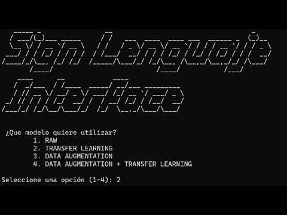